# **fuel consumption prediction**

### Target :

in this project, our goal is to fill-in the gaps of a detaset with the help of predicting statistical analysis.

### Description :

in this project, first we want to fill-in the empty cells using different metods such as fill them with mean number of other existing numbers in that column and then discuss about them. then we are going to find a Hypothesis Function, to find the best model for our dataset, wich can estimate the target column by considering one of the features in .csv file, . also, we need to analyze wich of the features in the file, is the best feature to be used as a measure, in order to predict the output, wich is the fuel consumption.

```python
import numpy as np
import matplotlib.pyplot as plt
import pandas as pd
import time

data = pd.read_csv("FuelConsumptionCo2.csv")
df = pd.DataFrame(data)
```

### Part 1 :

at first we read the FuelConsumptionCo2.csv file, wich contains some informations and featurs about different cars. we can read the .csv file and load it's datas with read_csv() function in pandas library. then with storage these datas into a datafram. and then we call .head(), .tail() and .describe() functions respectively. now we want to describe each function :

```python
print(df.head())
```

```
   MODEL  YEAR   MAKE     MODEL.1 VEHICLECLASS  ENGINESIZE  CYLINDERS  \
0      0  2014  ACURA         ILX      COMPACT         2.0        4.0
1      1  2014  ACURA         ILX      COMPACT         2.4        4.0
2      2  2014  ACURA  ILX HYBRID      COMPACT         1.5        4.0
3      3  2014  ACURA     MDX 4WD  SUV - SMALL         3.5        6.0
4      4  2014  ACURA     RDX AWD  SUV - SMALL         3.5        6.0

  TRANSMISSION FUELTYPE  FUELCONSUMPTION_CITY  FUELCONSUMPTION_HWY  \
0          AS5        Z                   9.9                  6.7
1           M6        Z                  11.2                  7.7
2          AV7        Z                   6.0                  5.8
3          AS6        Z                  12.7                  9.1
4          AS6        Z                  12.1                  8.7

   FUELCONSUMPTION_COMB  FUELCONSUMPTION_COMB_MPG  CO2EMISSIONS
0                   8.5                        33         196.0
1                   9.6                        29         221.0
2                   5.9                        48         136.0
3                  11.1                        25           NaN
4                  10.6                        27         244.0
```

```python
print(df.tail())
```

```
      MODEL  YEAR   MAKE   MODEL.1    VEHICLECLASS  ENGINESIZE  CYLINDERS  \
1062   1062  2014  VOLVO  XC60 AWD     SUV - SMALL         3.0        6.0
1063   1063  2014  VOLVO  XC60 AWD     SUV - SMALL         3.2        6.0
1064   1064  2014  VOLVO  XC70 AWD     SUV - SMALL         3.0        6.0
1065   1065  2014  VOLVO  XC70 AWD     SUV - SMALL         3.2        6.0
1066   1066  2014  VOLVO  XC90 AWD  SUV - STANDARD         3.2        6.0

     TRANSMISSION FUELTYPE  FUELCONSUMPTION_CITY  FUELCONSUMPTION_HWY  \
1062          AS6        X                  13.4                  9.8
1063          AS6        X                  13.2                  9.5
1064          AS6        X                  13.4                  9.8
1065          AS6        X                  12.9                  9.3
1066          AS6        X                  14.9                 10.2

      FUELCONSUMPTION_COMB  FUELCONSUMPTION_COMB_MPG  CO2EMISSIONS
1062                  11.8                        24         271.0
1063                  11.5                        25         264.0
1064                  11.8                        24         271.0
1065                  11.3                        25         260.0
1066                  12.8                        22         294.0
```

```python
print(df.describe ())
```

```
             MODEL    YEAR   ENGINESIZE    CYLINDERS  FUELCONSUMPTION_CITY  \
count  1067.000000  1067.0  1040.000000  1033.000000           1067.000000
mean    533.000000  2014.0     3.324038     5.797677             13.296532
std     308.160672     0.0     1.411400     1.807262              4.101253
min       0.000000  2014.0     1.000000     3.000000              4.600000
25%     266.500000  2014.0     2.000000     4.000000             10.250000
50%     533.000000  2014.0     3.300000     6.000000             12.600000
75%     799.500000  2014.0     4.200000     8.000000             15.550000
max    1066.000000  2014.0     8.400000    12.000000             30.200000

       FUELCONSUMPTION_HWY  FUELCONSUMPTION_COMB  FUELCONSUMPTION_COMB_MPG  \
count          1067.000000           1067.000000               1067.000000
mean              9.474602             11.580881                 26.441425
std               2.794510              3.485595                  7.468702
min               4.900000              4.700000                 11.000000
25%               7.500000              9.000000                 21.000000
50%               8.800000             10.900000                 26.000000
75%              10.850000             13.350000                 31.000000
max              20.500000             25.800000                 60.000000

       CO2EMISSIONS
count    964.000000
mean     256.741701
std       63.265308
min      108.000000
25%      209.000000
50%      251.000000
75%      294.000000
max      437.000000
```

**as we can see, these informations are only displayed for numeric columns and excluding Nan data values.**

**tail() :** this function, returns last 5 rows in the dataframe, wich is rows 1062-1066.

**describe() :** this function return some informations and basic statistical detail of a data frame. the output includes:

**1- count :** the number of exiting datas (not NAN values) in a coloumn.

**2- mean :** the average of existence datas in a column.

**3- std :** std is the Standard deviation of datas in a coloumn.

**4- min :** the minimum data in a column.

**5- 25/50/75% :** these perentages show 25th, 50th and 75th percentiles of the datas.

**6- max :** the maximum value in a column.

### Part 2 :

```python
df.info()
```

```
<class 'pandas.core.frame.DataFrame'>
RangeIndex: 1067 entries, 0 to 1066
Data columns (total 14 columns):
 #   Column                    Non-Null Count  Dtype
---  ------                    --------------  -----
 0   MODEL                     1067 non-null   int64
 1   YEAR                      1067 non-null   int64
 2   MAKE                      1067 non-null   object
 3   MODEL.1                   1058 non-null   object
 4   VEHICLECLASS              1067 non-null   object
 5   ENGINESIZE                1040 non-null   float64
 6   CYLINDERS                 1033 non-null   float64
 7   TRANSMISSION              1067 non-null   object
 8   FUELTYPE                  996 non-null    object
 9   FUELCONSUMPTION_CITY      1067 non-null   float64
 10  FUELCONSUMPTION_HWY       1067 non-null   float64
 11  FUELCONSUMPTION_COMB      1067 non-null   float64
 12  FUELCONSUMPTION_COMB_MPG  1067 non-null   int64
 13  CO2EMISSIONS              964 non-null    float64
dtypes: float64(6), int64(3), object(5)
memory usage: 116.8+ KB
```

```python
df["FUELTYPE"] = df["FUELTYPE"].replace(to_replace={'X' : 0 ,'E' : 1 ,'D' : 2, 'Z' : 3})
print(df["FUELTYPE"])
```

```
0       3.0
1       3.0
2       3.0
3       3.0
4       3.0
       ...
1062    0.0
1063    0.0
1064    0.0
1065    0.0
1066    0.0
Name: FUELTYPE, Length: 1067, dtype: float64
```

next we are going to replace the FUELTYPE column with numerical numbers. for doing so, we used replace() method in pandas library. this function would replace tthe given character with given assigned numbers as follow : {'X' : 0 ,'E' : 1 ,'D' : 2, 'Z' : 3}, the we printed out the data frame head() and tail() to see if it has worked or not. we can see that it has worked correctly by comparing it to head() and tail() of **part 1**.

### Part 3 :

```python
print(df[:].isna().sum())
```

```
MODEL                         0
YEAR                          0
MAKE                          0
MODEL.1                       9
VEHICLECLASS                  0
ENGINESIZE                   27
CYLINDERS                    34
TRANSMISSION                  0
FUELTYPE                     71
FUELCONSUMPTION_CITY          0
FUELCONSUMPTION_HWY           0
FUELCONSUMPTION_COMB          0
FUELCONSUMPTION_COMB_MPG      0
CO2EMISSIONS                103
dtype: int64
```

first we wanted to calculate the number of non NaN datas in each columns. so we used isna() function. this function returns the number of NaN or empty values. next we are going to fill-in these empty cells with their mean(for numericals) value or their mode(for categoricals).

```python
numericals = df.select_dtypes(include=['float64', 'int64'])
categoricals = df.select_dtypes(include=['object'])
encoded_column = numericals["FUELTYPE"]
numericals = numericals.drop(columns = ["FUELTYPE", "CO2EMISSIONS"])
print(numericals[48:53])
```

```
    MODEL  YEAR  ENGINESIZE  CYLINDERS  FUELCONSUMPTION_CITY  \
48     48  2014         NaN        8.0                  17.6
49     49  2014         4.2        8.0                  21.2
50     50  2014         5.2       10.0                  18.8
51     51  2014         5.2       10.0                  21.1
52     52  2014         4.2        8.0                  15.3

    FUELCONSUMPTION_HWY  FUELCONSUMPTION_COMB  FUELCONSUMPTION_COMB_MPG
48                 11.0                  14.6                        19
49                 13.4                  17.7                        16
50                 11.3                  15.4                        18
51                 13.8                  17.8                        16
52                 10.9                  13.3                        21
```

then we needed to separate the categorical datas from numericals. because we cant use mean value for categorical columns. instead we are going to fill them with their mode parameter(the parameter that shows most recently). so we separate them from each other so that so we can fill the emty cells in different ways. for separating the numerical values from categoricals, we used select_dtype() method to separate the columns by their type and save them in different dataframe. in this way FUELTYPE column would be in the numerical data frame but from previous part we know that this column was categorical and was replaced by numbers using Label Encoding. so we need to remove that from numericals data frame. also we dont want the target column to be in the dataframe. because we dont want to fill-in the NaN values here. so we remove these two columns with drop() method. for seeinig the existense of NaN values we have printed out rows 48-52 so that we can compare them with the result of next part.

```python
numericals = numericals.fillna(numericals.mean())
categoricals = categoricals.fillna(categoricals.mode())
encoded_column = encoded_column.fillna(encoded_column.mode())
print(numericals[48:53])
```

```
    MODEL  YEAR  ENGINESIZE  CYLINDERS  FUELCONSUMPTION_CITY  \
48     48  2014    3.324038        8.0                  17.6
49     49  2014    4.200000        8.0                  21.2
50     50  2014    5.200000       10.0                  18.8
51     51  2014    5.200000       10.0                  21.1
52     52  2014    4.200000        8.0                  15.3

    FUELCONSUMPTION_HWY  FUELCONSUMPTION_COMB  FUELCONSUMPTION_COMB_MPG
48                 11.0                  14.6                        19
49                 13.4                  17.7                        16
50                 11.3                  15.4                        18
51                 13.8                  17.8                        16
52                 10.9                  13.3                        21
```

```python
print(numericals.isna().sum())
```

```
MODEL                       0
YEAR                        0
ENGINESIZE                  0
CYLINDERS                   0
FUELCONSUMPTION_CITY        0
FUELCONSUMPTION_HWY         0
FUELCONSUMPTION_COMB        0
FUELCONSUMPTION_COMB_MPG    0
dtype: int64
```

```python
print(numericals.mean())
```

```
MODEL                        533.000000
YEAR                        2014.000000
ENGINESIZE                     3.324038
CYLINDERS                      5.797677
FUELCONSUMPTION_CITY          13.296532
FUELCONSUMPTION_HWY            9.474602
FUELCONSUMPTION_COMB          11.580881
FUELCONSUMPTION_COMB_MPG      26.441425
dtype: float64
```

for filling-in the NaN valuse with their mean or mode, we used a function called fillna() (wich is in pandas library)wich was discovered with a simple search in google. this function would get a value that is going to be replaced with the NaN values as an input. so for numerical data frame we used mean() method and for categorical dataframe and the encoded dataframe (FUELTYPE) with the mode() method. then we have showend these data frames and number of NaN values of them after applying this function and also data frames mean so that we can check if those NaN valuse of previous part was correct. wich as you can see the results its completely correct.

```python
test = df[df["CO2EMISSIONS"].isna() == True]
train = df[df["CO2EMISSIONS"].isna() == False]
print(test)
```

```
      MODEL  YEAR        MAKE              MODEL.1    VEHICLECLASS  \
3         3  2014       ACURA              MDX 4WD     SUV - SMALL
20       20  2014        AUDI           A4 QUATTRO         COMPACT
30       30  2014        AUDI                   A8        MID-SIZE
42       42  2014        AUDI                   Q7  SUV - STANDARD
43       43  2014        AUDI  Q7 TDI CLEAN DIESEL  SUV - STANDARD
...     ...   ...         ...                  ...             ...
1022   1022  2014  VOLKSWAGEN   BEETLE CONVERTIBLE      SUBCOMPACT
1027   1027  2014  VOLKSWAGEN                   CC         COMPACT
1051   1051  2014  VOLKSWAGEN               TIGUAN     SUV - SMALL
1052   1052  2014  VOLKSWAGEN               TIGUAN     SUV - SMALL
1053   1053  2014  VOLKSWAGEN       TIGUAN 4MOTION     SUV - SMALL

      ENGINESIZE  CYLINDERS TRANSMISSION  FUELTYPE  FUELCONSUMPTION_CITY  \
3            3.5        6.0          AS6       3.0                  12.7
```

[output cut: 38 more lines]

at the last part we splited out our data frame into those which their target column has a value and into those which is not.(its NaN) by using a simple assignment and isna() function wich was mentioned in previous parts. also , those rows that their target column had a value, are called train datas that we would find our prediction model out of them. and the other data fraim is called test, wich is going to be predicted using model that would be presented by training train datas.

### Part 4 :

```python
start = time.time()
ds = train["CO2EMISSIONS"]
dt = ds[ds < 240]
print(dt.mean())
end = time.time()
print(end - start)
```

```
201.122969837587
0.001994609832763672
```

```python
dt = ds[ds > 300]
print(dt.mean())
```

```
348.90232558139536
```

for counting the rows in our train data frame, we substract the data frame by applying a simple condition wich is the condition mentioned in the projet(their CO2EMISSIONS column value should be oart a) less than 240 and part b) more than 300). thenwe can simply calculate the avarege of them by using mean() method. next we used the same methos as we did in previous part to calculate the processing duration then by using time() function in time library we calculate the prossecing time in one of them.

### Part 5 :

```python
count = 0
total = 0

for i in ds:
    if i < 240:
        total += i
        count += 1

print(total / count)
```

```
201.122969837587
```

```python
start = time.time()
count = 0
total = 0

for i in ds:
    if 300 < i:
        count += 1

for i in ds:
    if 300 < i:
        total += i

print(total / count)
end = time.time()
print(end - start)
```

```
348.90232558139536
0.0020389556884765625
```

### Part6 :

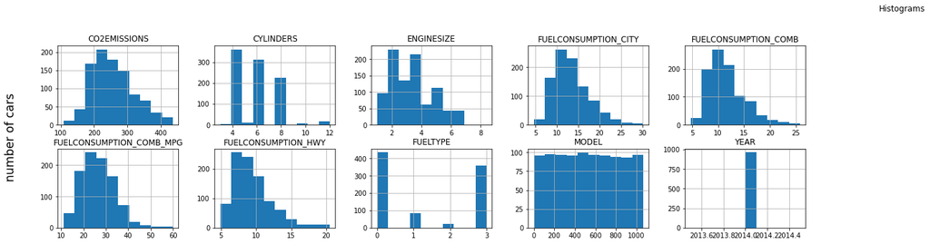

```python
headers = ["MODEL", "YEAR", "ENGINESIZE", "CYLINDERS", "FUELCONSUMPTION_CITY"
, "FUELCONSUMPTION_HWY", "FUELCONSUMPTION_COMB", "FUELCONSUMPTION_COMB_MPG"]
fig, axes = plt.subplots(nrows=2, ncols=5, sharex=False, sharey=False,figsize=(20,5))
train.hist(ax=axes)
plt.suptitle('Histograms', x=1, y=1.05, ha='center')
fig.text(0.07, 0.5, 'number of cars', va='center', rotation='vertical', fontsize='xx-large');
```

in this part we used hist() function in pandas library, to show the histogram plot of datas. we can wee for example model plot is similar to rectangle wich is because this data was fill by numbers 0-1066 so the histogram of it in every section is all the same. also we can see that year histogram has only one column wich means all datas are 2014. so we can see how the value in each column is distributed over all existing values.

### Part 7 :

```python
print(numericals)
numericals.insert(8, "CO2EMISSIONS",  df["CO2EMISSIONS"])
print(numericals)
numericals= numericals[numericals["CO2EMISSIONS"].isna() == False]
numericals = (numericals - numericals.mean()) / numericals.std()
print(numericals.head(), numericals.tail())
```

```
      MODEL  YEAR  ENGINESIZE  CYLINDERS  FUELCONSUMPTION_CITY  \
0         0  2014         2.0        4.0                   9.9
1         1  2014         2.4        4.0                  11.2
2         2  2014         1.5        4.0                   6.0
3         3  2014         3.5        6.0                  12.7
4         4  2014         3.5        6.0                  12.1
...     ...   ...         ...        ...                   ...
1062   1062  2014         3.0        6.0                  13.4
1063   1063  2014         3.2        6.0                  13.2
1064   1064  2014         3.0        6.0                  13.4
1065   1065  2014         3.2        6.0                  12.9
1066   1066  2014         3.2        6.0                  14.9

      FUELCONSUMPTION_HWY  FUELCONSUMPTION_COMB  FUELCONSUMPTION_COMB_MPG
0                     6.7                   8.5                        33
```

[output cut: 91 more lines]

in this part we normilize our datas in train data frame by substract the mean value of each column and then devide it into std(standard deviation). in this case all datas would act same because all the average of all columns would be 0 and their std would be 1. we can see the resulst that all datas have been changed.

### Part 8:

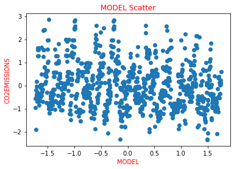

[figure not shown]

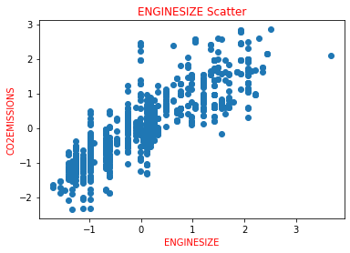

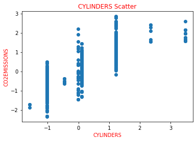

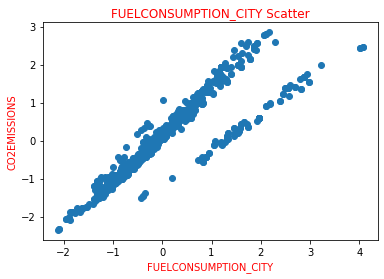

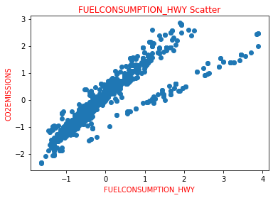

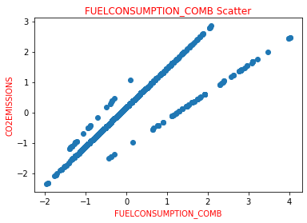

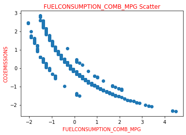

```python
for head in headers:
    plt.scatter(numericals[head], numericals["CO2EMISSIONS"])
    plt.ylabel("CO2EMISSIONS", color = "red")
    plt.xlabel(head, color = "red")
    plt.title(f"{head} Scatter", color = "red")
    plt.show()
```

### Part 9 :

```python
newdataframe = numericals[["FUELCONSUMPTION_COMB" , "CO2EMISSIONS"]]
print(newdataframe)
```

```
      FUELCONSUMPTION_COMB  CO2EMISSIONS
0                -0.888216     -0.960111
1                -0.576247     -0.564949
2                -1.625596     -1.908498
4                -0.292640     -0.201401
5                -0.462804     -0.422691
...                    ...           ...
1062              0.047690      0.225373
1063             -0.037393      0.114728
1064              0.047690      0.225373
1065             -0.094114      0.051502
1066              0.331297      0.588921

[964 rows x 2 columns]
```

```python
X = newdataframe["FUELCONSUMPTION_COMB"]
Y = newdataframe["CO2EMISSIONS"]
XX = X*X
XY = X*Y

teta0 = ((Y.sum() * XX.sum()) - (X.sum() * XY.sum())) / ((len(X) * XX.sum()) - np.power(X.sum(),2))
teta1 = ((len(X) * XY.sum()) -  (X.sum() * Y.sum())) / ((len(X) * XX.sum()) - np.power(X.sum(),2))
```

in this part we used a linear regression model for modeling and hypotheses our data frame test values. the reason for using this method is because its obtained by makeing the error minimum by minimizing the gradinant of the line equation and MSE error. i've been using this method using my own knowlege that i've learned from physic 1-laboratory course in university. in this part we have used 2 equations to calculate the tata1 and teta0. the proof for this equations is brought in following(img1):

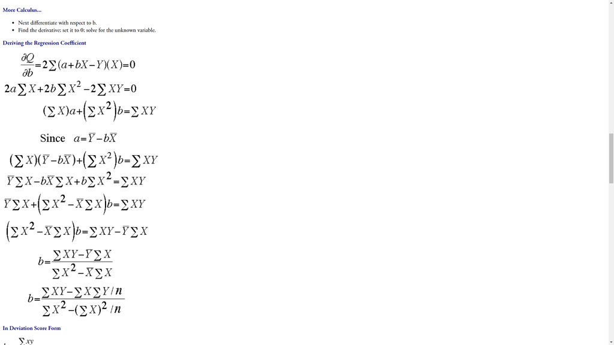

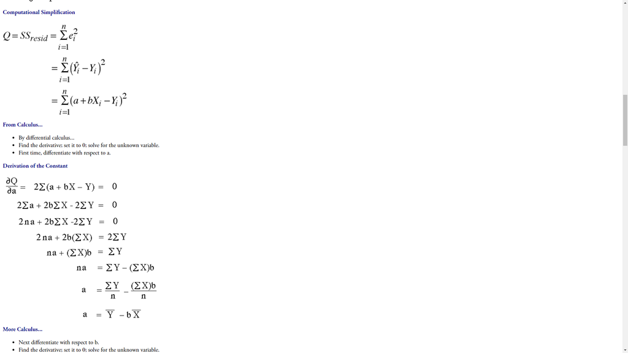

### img1-regression proof

### Part 10 :

```python
dif = Y - (teta1 * X) + teta0
MSE = dif.sum() / len(X)
print(MSE)
if (MSE < 0.5):
    print("its right!")
else:
    print("its not good!")
```

```
3.3573881342191455e-15
its right!
```

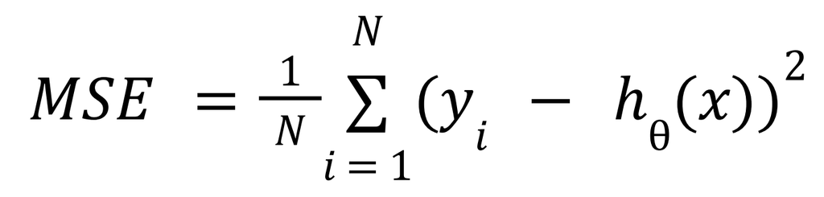

### img2-MSE equation

### Part 11 :

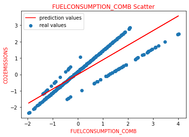

```python
plt.scatter(newdataframe["FUELCONSUMPTION_COMB"], newdataframe["CO2EMISSIONS"], label = "real values")
plt.plot( X,teta1*X + teta0, color = "red", label = "prediction values")
plt.ylabel("CO2EMISSIONS", color = "red")
plt.xlabel("FUELCONSUMPTION_COMB",color = "red")
plt.title("FUELCONSUMPTION_COMB Scatter", color = "red")
plt.legend()
plt.show()
```

in this part we plot the scatter plot of real otputs and the prediction output in a same plot. the red one is the prediction plot and the blue scatter plot is fore real outputs. az we can see the plot are so close to each other and is a good prediction of this feature because it is mostly close to the blue line that we can see in the plot but also because of the other datas in the data frame wich are not close to the blue line, the red line is a little bit turn in clockwise direction.

### Part 12 :

```python
test = test[["FUELCONSUMPTION_COMB" , "CO2EMISSIONS"]]
test = (test - test.mean()) / test.std()
print(test)
```

```
      FUELCONSUMPTION_COMB  CO2EMISSIONS
3                -0.001271           NaN
20               -0.361210           NaN
30                0.031451           NaN
42                0.685885           NaN
43               -0.066714           NaN
...                    ...           ...
1022             -0.557540           NaN
1027             -0.426653           NaN
1051             -0.132158           NaN
1052              0.162338           NaN
1053             -0.132158           NaN

[103 rows x 2 columns]
```

```python
test["CO2EMISSIONS"] = test["CO2EMISSIONS"].fillna(teta1*test["FUELCONSUMPTION_COMB"] + teta0)
print(test)
```

```
      FUELCONSUMPTION_COMB  CO2EMISSIONS
3                -0.001271     -0.001129
20               -0.361210     -0.321002
30                0.031451      0.027950
42                0.685885      0.609537
43               -0.066714     -0.059288
...                    ...           ...
1022             -0.557540     -0.495478
1027             -0.426653     -0.379161
1051             -0.132158     -0.117447
1052              0.162338      0.144268
1053             -0.132158     -0.117447

[103 rows x 2 columns]
```

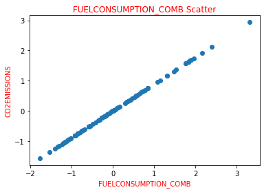

```python
plt.scatter(test["FUELCONSUMPTION_COMB"], test["CO2EMISSIONS"])
plt.ylabel("CO2EMISSIONS", color = "red")
plt.xlabel("FUELCONSUMPTION_COMB", color = "red")
plt.title("FUELCONSUMPTION_COMB Scatter", color = "red")
```

### Result :

we can predict some missing datas and also our target outputs, using other available datas and their distribudistributions.

### References :

https://pandas.pydata.org/pandas-docs/stable/reference/general_functions.html

https://realpython.com/numpy-array-programming/

https://numpy.org/doc/stable/reference/routines.math.html

https://datatofish.com/count-nan-pandas-dataframe/

https://owlcation.com/stem/How-to-Create-a-Simple-Linear-Regression-Equation

http://www.philender.com/courses/multivariate/notes2/slr0.html

https://realpython.com/linear-regression-in-python/#:~:text=Simple%20Linear%20Regression%20With%20scikit-learn%201%20Import%20packages,for%20predictions%20with%20either%20existing%20or%20new%20data.